# 03_further_EDA

Andrea Polazzi

2026-03-10

# Setup

Let’s do another EDA, but this time let’s see if there are any differences correlating **telomere length** to variables such as **TF rates**, **TVR norm. by all reads** or **TVR norm. by intratel. reads**.

First of all, we must load the dataset and the required packages:

```r
library(readxl)
library(ggplot2)
data <- read_xlsx("../data/raw/drivers.xlsx")
```

And rename/remove duplicate columns, along with awkwardly named ones:

```r
source('../scripts/clean_columns.R')
clean_data <- clean_drivers_data(data)
```

Let’s create the subset that we need (the column `tel_reads/total reads` can be considered as a representative of telomere length):

```r
tel_data <- unique(
  clean_data[, c(
    'patient_id',
    'tumor_tf_rate',
    'tel_reads/total reads',
    'tel_reads/total reads_ORDER',
    'tvr_all',
    'tvr_intratel'
  )]
)
summary(tel_data)
```

```
##   patient_id        tumor_tf_rate      tel_reads/total reads
##  Length:3934        Min.   : 0.00000   Min.   :1.020e-05
##  Class :character   1st Qu.: 0.00000   1st Qu.:3.084e-05
##  Mode  :character   Median : 0.02125   Median :4.166e-05
##                     Mean   : 0.07024   Mean   :5.149e-05
##                     3rd Qu.: 0.05481   3rd Qu.:5.585e-05
##                     Max.   :51.19476   Max.   :2.095e-03
##  tel_reads/total reads_ORDER    tvr_all           tvr_intratel
##  Min.   :   1                Min.   :2.070e-08   Min.   :0.001848
##  1st Qu.:1029                1st Qu.:8.228e-08   1st Qu.:0.006007
##  Median :2056                Median :1.093e-07   Median :0.007313
##  Mean   :2063                Mean   :1.357e-07   Mean   :0.007804
##  3rd Qu.:3090                3rd Qu.:1.443e-07   3rd Qu.:0.008889
##  Max.   :4159                Max.   :8.392e-06   Max.   :0.069542
```

# Correlation between Telomere Length and all other features

## Telomere Length vs TVR norm. by total reads

We choose Spearman as our correlation method since it deals with monotonic, non-parametric relationships. Pearson’s correlation has some assumptions that do not hold true in most biological data: normality and absence of outliers

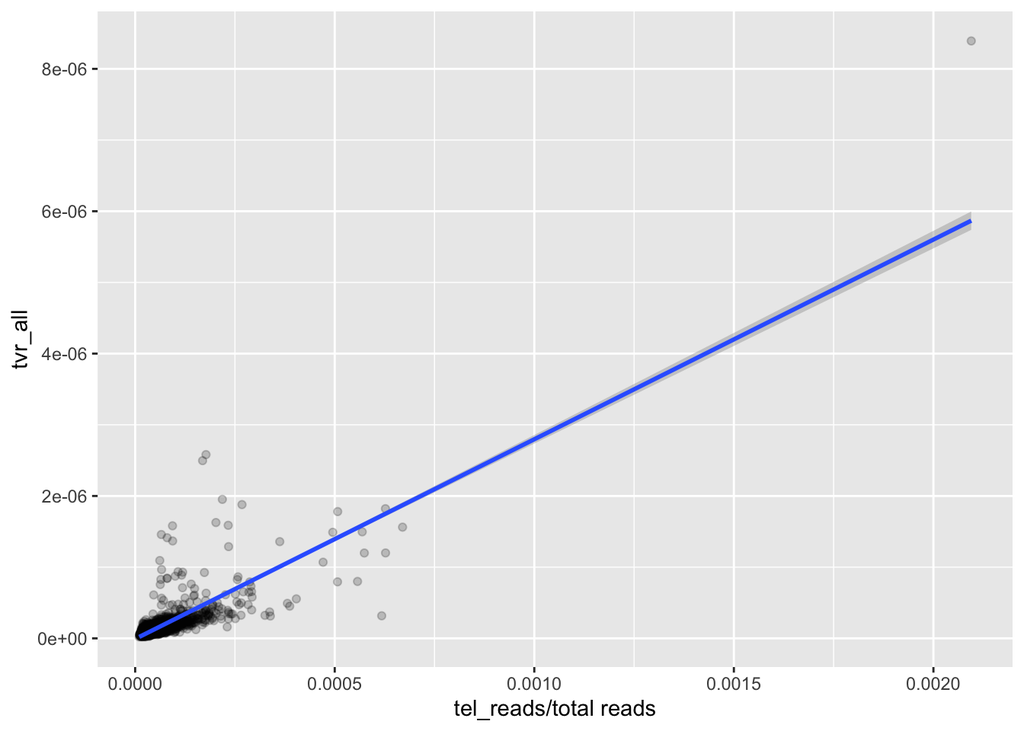

```r
ggplot(tel_data, aes(`tel_reads/total reads`, tvr_all)) +
  geom_point(alpha=0.2) +
  geom_smooth(method = "lm", se = T)
```

```r
cor.test(tel_data$`tel_reads/total reads`, tel_data$tvr_all, method = 'spearman')
```

```
##
##  Spearman's rank correlation rho
##
## data:  tel_data$`tel_reads/total reads` and tel_data$tvr_all
## S = 3010208153, p-value < 2.2e-16
## alternative hypothesis: true rho is not equal to 0
## sample estimates:
##       rho
## 0.7033497
```

## Telomere Length vs TVR norm. by intratel reads

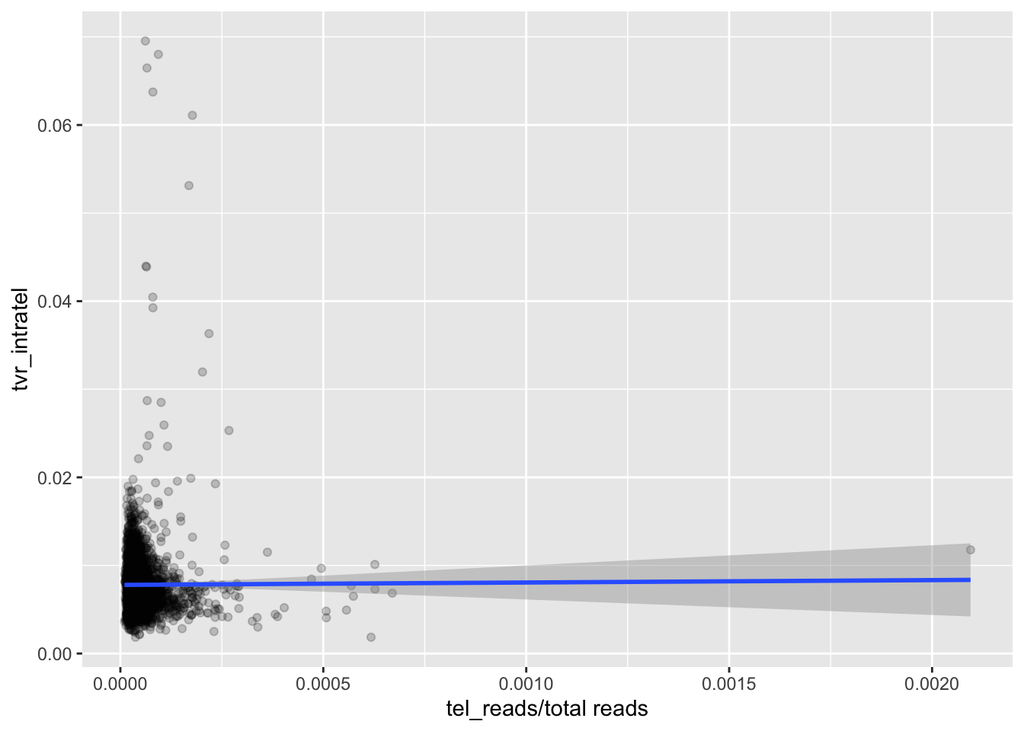

```r
ggplot(tel_data, aes(`tel_reads/total reads`, tvr_intratel)) +
  geom_point(alpha=0.2) +
  geom_smooth(method = "lm", se = T)
```

```r
cor.test(tel_data$`tel_reads/total reads`, tel_data$tvr_intratel, method = 'spearman')
```

```
##
##  Spearman's rank correlation rho
##
## data:  tel_data$`tel_reads/total reads` and tel_data$tvr_intratel
## S = 1.0903e+10, p-value = 2.938e-06
## alternative hypothesis: true rho is not equal to 0
## sample estimates:
##         rho
## -0.07445803
```

Here we see a **weak, negative relatioship** (ρ = -0.074), **almost flat**, suggesting that **TVR density inside telomeres is largely independent of telomere length**.

## Telomere Length vs log(1+TF rate)

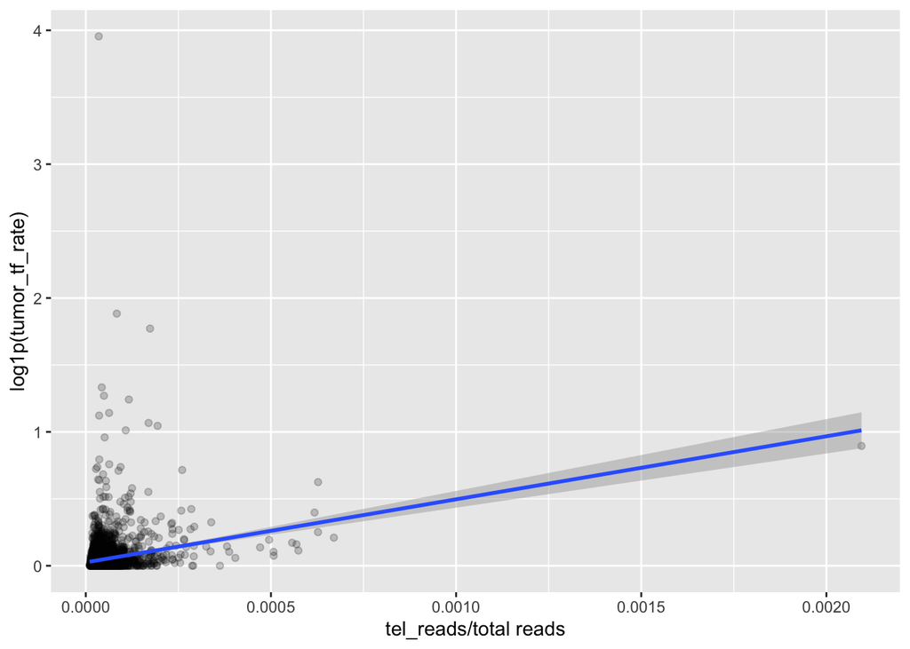

```r
ggplot(tel_data, aes(`tel_reads/total reads`, log1p(tumor_tf_rate))) +
  geom_point(alpha=0.2) +
  geom_smooth(method = "lm", se = T)
```

```r
cor.test(tel_data$`tel_reads/total reads`, log1p(tel_data$tumor_tf_rate), method = 'spearman')
```

```
##
##  Spearman's rank correlation rho
##
## data:  tel_data$`tel_reads/total reads` and log1p(tel_data$tumor_tf_rate)
## S = 9.122e+09, p-value = 2.128e-10
## alternative hypothesis: true rho is not equal to 0
## sample estimates:
##       rho
## 0.1010425
```

As regards the TF rate (log transformed) we see that telomere length is **positively yet weakly correlated** with it.

```r
model <- lm(log1p(tumor_tf_rate)~`tel_reads/total reads`, data=tel_data)
summary(model)
```

```
##
## Call:
## lm(formula = log1p(tumor_tf_rate) ~ `tel_reads/total reads`,
##     data = tel_data)
##
## Residuals:
##     Min      1Q  Median      3Q     Max
## -0.1960 -0.0415 -0.0251  0.0053  3.9132
##
## Coefficients:
##                          Estimate Std. Error t value Pr(>|t|)
## (Intercept)             2.542e-02  2.537e-03   10.02   <2e-16 ***
## `tel_reads/total reads` 4.709e+02  3.361e+01   14.01   <2e-16 ***
## ---
## Signif. codes:  0 '***' 0.001 '**' 0.01 '*' 0.05 '.' 0.1 ' ' 1
##
## Residual standard error: 0.1164 on 3932 degrees of freedom
## Multiple R-squared:  0.04756,    Adjusted R-squared:  0.04731
## F-statistic: 196.3 on 1 and 3932 DF,  p-value: < 2.2e-16
```